# Intensifiers: Replication Experiment

Erin Bennett

## Experiment

Rating experiment.

## Planned analysis

### 1. Reformat data

We first excluded any participants who are not native speakers of English or who stated that they did not think they followed instructions.

People represent prices logarithmically, so we log-transform all of the prices that participants entered.

We don’t care about modeling the prices of the individual objects. We think that this factor might interact with participants (different participants have different beliefs about price distributions for different objects), but we do not have enough data to fit an accurate mixed model with interacting random effects. So we z-score within each participant’s ratings for each object (Thanks, Reviewer, for the suggestion!).

Here’s the original data. The slopes and intercepts vary by both participants and objects. In particular, watches seem to have larger slopes than laptops.

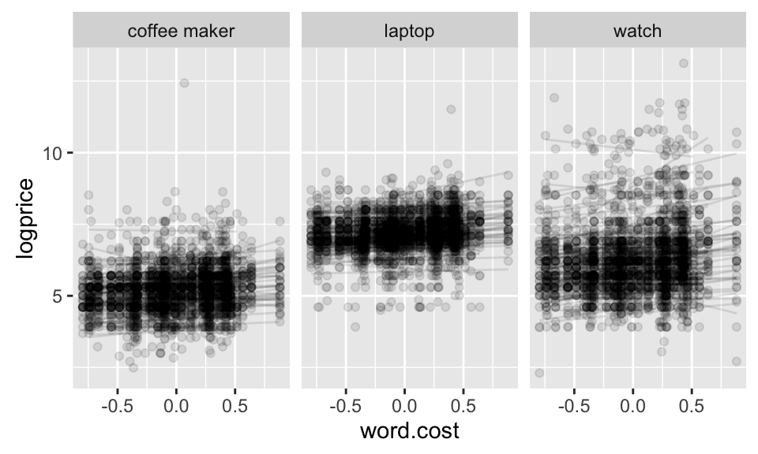

And here’s what the data look like when we z-score within each participant’s responses for each object. Now each participant has an intercept of zero (kind of obviously…), but the slopes vary across participants.

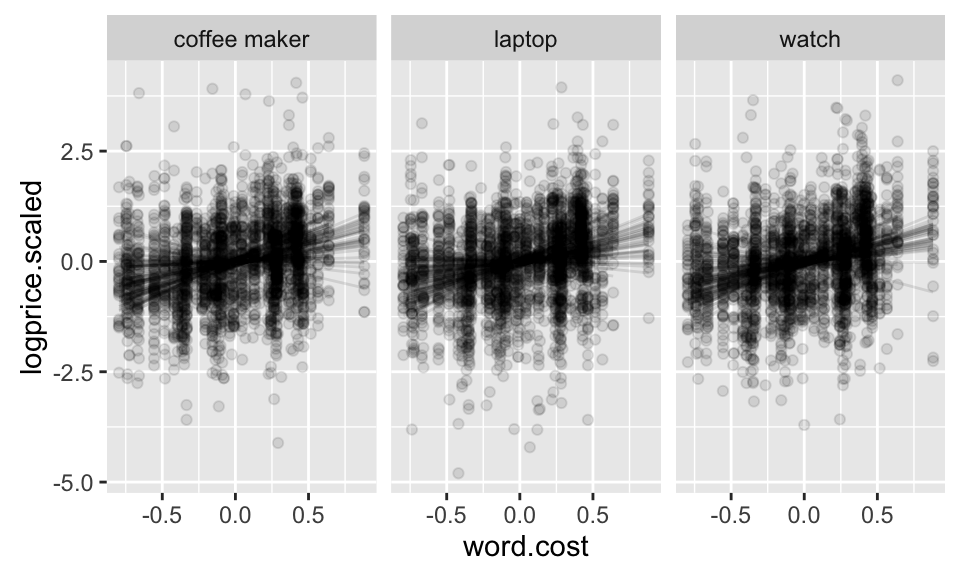

### 2. Model

Given that preprocessing involves normalizing responses from each participant for each item, we would use the following model, which includes a random slope for participant but no random intercept. We include random intercepts for intensifier (the particular words). We center the continuous predictors by subtracting their means.

```r
m = lmer(logprice.scaled ~ 1 + syll.centered * surprisal.centered +
    (0 + syll.centered + surprisal.centered | workerid) +
    (1 | intensifier), df)
```

```
## Linear mixed model fit by REML t-tests use Satterthwaite approximations
##   to degrees of freedom [lmerMod]
## Formula: logprice.scaled ~ 1 + syll.centered * surprisal.centered + (0 +
##     syll.centered + surprisal.centered | workerid) + (1 | intensifier)
##    Data: df
##
## REML criterion at convergence: 19183.5
##
## Scaled residuals:
##     Min      1Q  Median      3Q     Max
## -5.0004 -0.6095  0.0186  0.6317  5.6460
##
## Random effects:
##  Groups      Name               Variance Std.Dev. Corr
##  workerid    syll.centered      0.003207 0.05663
##              surprisal.centered 0.001937 0.04401  0.58
##  intensifier (Intercept)        0.151343 0.38903
##  Residual                       0.713387 0.84462
## Number of obs: 7536, groups:  workerid, 106; intensifier, 71
##
## Fixed effects:
##                                  Estimate Std. Error       df t value
## (Intercept)                      -0.08707    0.05866 66.97000  -1.484
## syll.centered                     0.03232    0.05269 68.34000   0.614
## surprisal.centered                0.14040    0.03452 68.79000   4.068
## syll.centered:surprisal.centered  0.05976    0.02384 66.81000   2.506
##                                  Pr(>|t|)
## (Intercept)                      0.142468
## syll.centered                    0.541560
## surprisal.centered               0.000125 ***
## syll.centered:surprisal.centered 0.014642 *
## ---
## Signif. codes:  0 '***' 0.001 '**' 0.01 '*' 0.05 '.' 0.1 ' ' 1
##
## Correlation of Fixed Effects:
##             (Intr) syll.c srprs.
## syll.centrd  0.103
## srprsl.cntr -0.232 -0.628
## syll.cntr:. -0.593 -0.181  0.398
```

We did not replicate our original model.

```
## Linear mixed model fit by REML t-tests use Satterthwaite approximations
##   to degrees of freedom [lmerMod]
## Formula:
## logprice ~ surprisal + syll + (1 + surprisal + syll | workerid) +
##     (1 + surprisal + syll | object)
##    Data: df
##
## REML criterion at convergence: 17736.4
##
## Scaled residuals:
##     Min      1Q  Median      3Q     Max
## -4.5675 -0.5715 -0.0213  0.5316  7.6533
##
## Random effects:
##  Groups   Name        Variance  Std.Dev. Corr
##  workerid (Intercept) 0.2276988 0.47718
##           surprisal   0.0002262 0.01504  -0.02
##           syll        0.0004374 0.02091   0.32  0.94
##  object   (Intercept) 1.2481332 1.11720
##           surprisal   0.0003507 0.01873  -0.73
##           syll        0.0003488 0.01868   0.65  0.05
##  Residual             0.5810851 0.76229
## Number of obs: 7536, groups:  workerid, 106; object, 3
##
## Fixed effects:
##             Estimate Std. Error      df t value Pr(>|t|)
## (Intercept)  5.54111    0.64928 2.03310   8.534   0.0128 *
## surprisal    0.04847    0.01245 2.20630   3.895   0.0511 .
## syll         0.03622    0.01498 2.88700   2.417   0.0977 .
## ---
## Signif. codes:  0 '***' 0.001 '**' 0.01 '*' 0.05 '.' 0.1 ' ' 1
##
## Correlation of Fixed Effects:
##           (Intr) srprsl
## surprisal -0.667
## syll       0.484 -0.164
```

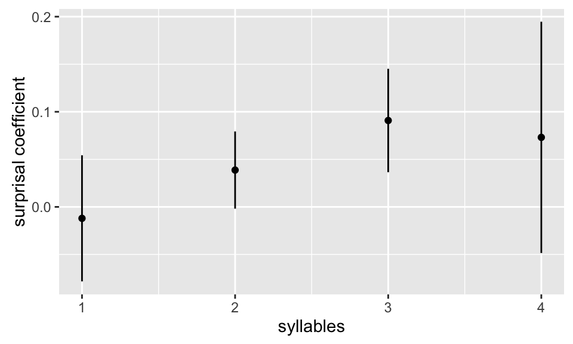

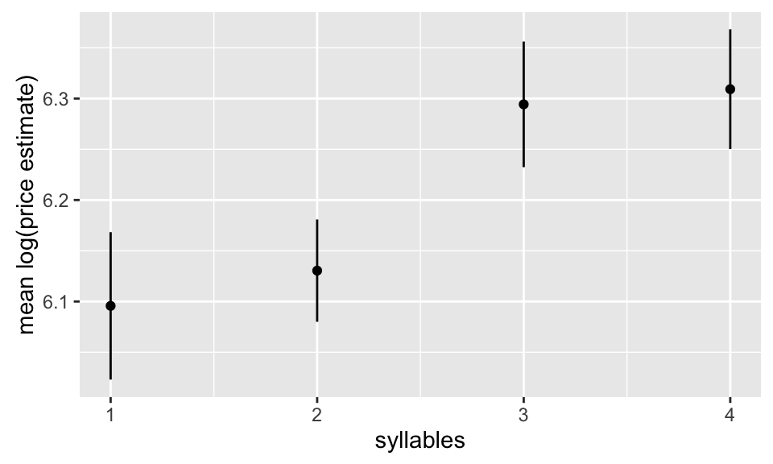

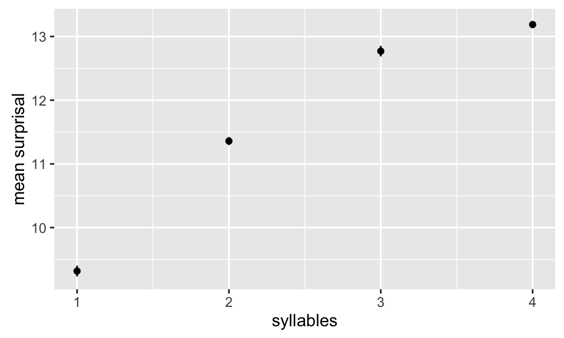

```
## # A tibble: 8 × 2
##    syll     n
##   <dbl> <int>
## 1   1.0    10
## 2   2.0    22
## 3   3.0    16
## 4   3.5     1
## 5   4.0    18
## 6   4.5     1
## 7   5.0     2
## 8   6.5     1
```